# Data Mining Project - Analysis of Airbnb Rentals

Tara Cool

# Introduction

New York City’s Airbnb rental market is a dynamic and diverse ecosystem, attracting global travelers and property owners. This data mining project delves into this complex landscape to extract valuable insights that inform decision-making for various stakeholders.

**Data Preparation & Exploration**

The project commences with a comprehensive Data Preparation & Exploration phase, involving the identification and treatment of missing values, handling of outliers, computation of summary statistics, and the creation of insightful data visualizations. These visualizations illuminate pricing trends, accommodation preferences, correlations, categorical listing characteristics, and host verification, providing stakeholders with valuable insights into the Airbnb market’s intricacies.

**Prediction**

Subsequently, the project advances to the Prediction phase, utilizing multiple regression techniques to forecast Airbnb rental prices in New York City. The model incorporates diverse factors, including accommodation capacity and location, to offer pricing insights beneficial for both hosts and guests. While the model explains a significant portion of price variability, it also highlights unaccounted-for factors, prompting further exploration and refinement.

**Classification**

In the Classification phase, the project harnesses Naive Bayes classification to categorize rental prices into distinct bins, revealing pricing categories catering to diverse preferences and budgets. This classification extends to predicting cancellation policies, shedding light on the factors influencing these decisions for both hosts and guests.

**Clustering - Comparison of Neighborhoods in NYC**

Concluding the project, we explore Brooklyn’s neighborhoods through k-Means clustering. By analyzing various features, we identify distinct clusters characterized by unique attributes. This analysis aids property investors, tourists, and urban planners in data-driven decision-making for Brooklyn’s neighborhoods.

In summary, this data mining project offers a comprehensive exploration of the Airbnb rental market in New York City, supported by data visualizations that provide stakeholders with a clear understanding of market dynamics. It serves as a blueprint for similar analyses in bustling urban areas worldwide.*

```r
# Load required packages
library(scales)
library(data.table)
library(stats)
library(ggplot2)
library(dplyr)
library(forcats)
library(forecast)
library(caret)
library(tidyverse)
library(FNN)
library(ggcorrplot)
library(e1071)
library(rpart)
library(rpart.plot)
library(factoextra)
library(ggpubr)
library(pROC)
```

# **1. Data Preparation & Exploration**

```r
# Read data into local environment
df <- read.csv("train.csv")
```

```r
# Subset data frame to include only those records pertaining to NYC
ny.df <- df[df$city == "NYC", ]
```

## **a. Handling Missing Values/Data Pre-Processing**

```r
# Convert blank cells to 'NA's
ny.df[ny.df == ""] <- NA

# Calculate number of 'NA' values in data frame
sum(is.na(ny.df))
```

```
[1] 34579
```

```r
# Get percentage of rows that are "complete cases" (i.e., not missing values)
percent(sum(complete.cases(ny.df))/nrow(ny.df), accuracy = 0.01)
```

```
[1] "55.20%"
```

Evaluate count/proportion of ‘NA’ values corresponding to each variable to understand the potential impact of dropping/imputing these missing values:

```r
# Subset columns that contain "NA" values & get count of NA values in each column
num_NAs <- colSums(is.na(ny.df))

# Compute percent of NA values in each column
prop_NAs <- percent(num_NAs/nrow(ny.df), accuracy = 0.01)

# Create df to store missing value counts for each variable
var_NAs.df <- data.frame(num_NAs, prop_NAs)

# Convert to table
var_NAs <- data.table(var_NAs.df, keep.rownames = TRUE)
colnames(var_NAs) <- c("Variable", "Num. of NAs", "% NAs")

var_NAs  # print table
```

| Variable | Num. of NAs | % NAs |
| --- | --- | --- |
| id | 0 | 0.00% |
| log_price | 0 | 0.00% |
| property_type | 0 | 0.00% |
| room_type | 0 | 0.00% |
| amenities | 0 | 0.00% |
| accommodates | 0 | 0.00% |
| bathrooms | 99 | 0.31% |
| bed_type | 0 | 0.00% |
| cancellation_policy | 0 | 0.00% |
| cleaning_fee | 0 | 0.00% |

[output cut: 19 more lines]

*These insights will guide our process in deciding how we will handle NA values (e.g., drop or impute) for each data mining task (e.g., prediction, classification, & clustering)*

```r
# Handle missing values for numerical variables by imputing with median

# Convert 'host_response_rate' from character value to numerical
ny.df$host_response_rate <- as.numeric(sub("%", " ", ny.df$host_response_rate))

# Impute for missing values with median
ny.df$bathrooms[is.na(ny.df$bathrooms)] <- median(ny.df$bathrooms, na.rm = TRUE)
ny.df$host_response_rate[is.na(ny.df$host_response_rate)] <- median(ny.df$host_response_rate, na.rm = TRUE)
ny.df$review_scores_rating[is.na(ny.df$review_scores_rating)] <- median(ny.df$review_scores_rating, na.rm = TRUE)
ny.df$bedrooms[is.na(ny.df$bedrooms)] <- median(ny.df$bedrooms, na.rm = TRUE)
ny.df$beds[is.na(ny.df$beds)] <- median(ny.df$beds, na.rm = TRUE)
```

*The decision to impute missing values for numerical variables, such as ‘host_response_rate,’ ‘bathrooms,’ ‘review_scores_rating,’ ‘bedrooms,’ and ‘beds,’ with their respective medians serves the purpose of preserving the data’s central tendencies while reducing the potential impact of outliers.*

*In summary, during this phase of data preparation and exploration, we identify and address missing values, including those within empty cells. Imputing missing values with median values is a chosen approach to maintain data integrity while taking outliers into account. This comprehensive approach guarantees data quality and completeness, laying a strong foundation for effective data mining tasks.*

```r
# Drop NA values for categorical variables that were not imputed
ny.df <- na.omit(ny.df)
```

```r
# Subset values not equal to 0, as 0 is unrealistic for many numeric variables
ny.df <- ny.df %>% filter(log_price > 0)
ny.df <- ny.df %>% filter(accommodates > 0)
ny.df <- ny.df %>% filter(bathrooms > 0)
ny.df <- ny.df %>% filter(number_of_reviews > 0)
ny.df <- ny.df %>% filter(review_scores_rating > 0)
ny.df <- ny.df %>% filter(bedrooms > 0)
```

```r
# Convert 'host_response_rate' & 'review_scores_rating' to decimal values that denote percentages
ny.df$host_response_rate <- round((ny.df$host_response_rate)/100, 2)
ny.df$review_scores_rating <- round((ny.df$review_scores_rating)/100, 2)
```

```r
# Subset of valid 'zipcode' values
valid_zipcode <- nchar(ny.df$zipcode) == 5

# Filter dataframe to keep only those rows with valid zipcodes
ny.df <- ny.df[valid_zipcode, ]
```

```r
# Convert 't'/'f' to 'True'/'False'
ny.df$host_identity_verified <- factor(ny.df$host_identity_verified, levels = c("t", "f"), labels = c("True", "False"))
ny.df$instant_bookable <- factor(ny.df$instant_bookable, levels = c("t", "f"), labels = c("True", "False"))
```

### **Feature Engineering**

*In this section, we will simplify several categorical variables by minimizing the number of categories/levels for variables like ‘bed_type’ & ‘cancellation_policy.’ We will also define several new variables using a combination of the existing variables in the dataset & external data. In particular, we will define the variables ‘borough’, ‘amenities_list’, & ‘amenities_count’.*

Simplify categorical variables:

```r
# Group less common levels of 'bed_type' into a single column called 'Other' (keep only the most frequently occurring type of bed)
ny.df$bed_type <- fct_lump(ny.df$bed_type, 1)

# Combine levels 'super_strict_30' & 'super_strict_60' from the variable 'cancellation_policy' & creating new category called 'super_strict'
ny.df$cancellation_policy <- fct_other(ny.df$cancellation_policy, keep = c("flexible", "moderate", "strict"), other_level = "super_strict")
```

Define new variable ‘borough’:

```r
# Import dataset for mapping zipcodes to boroughs
borough_df <- read.csv("nyc_zip_borough_neighborhoods_pop.csv")

# Inspect dataset
str(borough_df)
```

```
'data.frame':   177 obs. of  6 variables:
 $ zip         : int  10001 10002 10003 10004 10005 10006 10007 10009 10010 10011 ...
 $ borough     : chr  "Manhattan" "Manhattan" "Manhattan" "Manhattan" ...
 $ post_office : chr  "New York, NY" "New York, NY" "New York, NY" "New York, NY" ...
 $ neighborhood: chr  "Chelsea and Clinton" "Lower East Side" "Lower East Side" "Lower Manhattan" ...
 $ population  : int  21102 81410 56024 3089 7135 3011 6988 61347 31834 50984 ...
 $ density     : int  33959 92573 97188 5519 97048 32796 42751 99492 81487 77436 ...
```

Note: The dataset with information about the zipcode to borough mappings was downloaded/imported from the link below … [Zipcode to NYC Borough Mappings Dataset](https://data.beta.nyc/dataset/pediacities-nyc-neighborhoods/resource/7caac650-d082-4aea-9f9b-3681d568e8a5)

```r
# Subset necessary variables
borough_zip_df <- borough_df[, c("zip", "borough")]

# Convert 'zip' to character type
borough_zip_df$zip <- as.character(borough_zip_df$zip)

# Merge new dataset with Airbnb dataframe based on 'zipcode' variable
ny.df <- merge(ny.df, borough_zip_df, by.x = "zipcode", by.y = "zip", all.x = TRUE)

# Replace missing 'borough' values with "Other"
ny.df$borough[is.na(ny.df$borough)] <- "Other"

# Drop 'zipcode' from dataset
ny.df <- subset(ny.df, select = -c(zipcode))
```

Define new variables ‘amenities_list’ & ‘amenities_count’:

```r
# Define list of amenities & count of amenities for each listing
ny.df <- ny.df %>%
  mutate(amenities_list = strsplit(amenities, ",")) %>%
  mutate(amenities_count = lengths(amenities_list))

# Drop now redundant 'amenities_list' variable
ny.df <- subset(ny.df, select = -c(amenities_list))
```

## **b. Summary Statistics**

```r
# Drop NA values for categorical variables that were not imputed
ny.df <- na.omit(ny.df)
```

Identify numeric & categorical variables:

```r
# Subset numeric columns
num_var <- ny.df[, sapply(ny.df, is.numeric)]

# Subset remaining (categorical) columns
cat_var <- ny.df[, !(names(ny.df) %in% names(num_var))]

# Drop unique identifier columns from subsets
num_var <- subset(num_var, select = -c(id))
cat_var <- subset(cat_var, select = -c(description, name, thumbnail_url))
```

```r
# Get summary stats for numerical variables
summary(num_var)
```

```
   log_price      accommodates     bathrooms     host_response_rate
 Min.   :2.303   Min.   : 1.00   Min.   :0.500   Min.   :0.0000
 1st Qu.:4.174   1st Qu.: 2.00   1st Qu.:1.000   1st Qu.:1.0000
 Median :4.605   Median : 2.00   Median :1.000   Median :1.0000
 Mean   :4.676   Mean   : 2.96   Mean   :1.142   Mean   :0.9643
 3rd Qu.:5.106   3rd Qu.: 4.00   3rd Qu.:1.000   3rd Qu.:1.0000
 Max.   :7.600   Max.   :16.00   Max.   :5.500   Max.   :1.0000
    latitude       longitude      number_of_reviews review_scores_rating
 Min.   :40.51   Min.   :-74.24   Min.   :  1.00    Min.   :0.2000
 1st Qu.:40.69   1st Qu.:-73.98   1st Qu.:  3.00    1st Qu.:0.9100
 Median :40.73   Median :-73.95   Median :  9.00    Median :0.9600
 Mean   :40.73   Mean   :-73.95   Mean   : 23.49    Mean   :0.9355
 3rd Qu.:40.77   3rd Qu.:-73.93   3rd Qu.: 29.00    3rd Qu.:1.0000
 Max.   :40.90   Max.   :-73.72   Max.   :465.00    Max.   :1.0000
    bedrooms           beds        amenities_count
 Min.   : 1.000   Min.   : 1.000   Min.   : 1.00
 1st Qu.: 1.000   1st Qu.: 1.000   1st Qu.:13.00
 Median : 1.000   Median : 1.000   Median :16.00
 Mean   : 1.282   Mean   : 1.639   Mean   :17.36
 3rd Qu.: 1.000   3rd Qu.: 2.000   3rd Qu.:21.00
 Max.   :10.000   Max.   :18.000   Max.   :77.00
```

```r
# Standard deviation of each variable to better understand its overall distribution
options(scipen = 999)
col.sd <- apply(num_var, 2, sd)
col.sd  # print 'sd' object (vector of sd values for each column)
```

```
           log_price         accommodates            bathrooms
          0.65846055           1.91204701           0.40526714
  host_response_rate             latitude            longitude
          0.11874684           0.05767564           0.04550813
   number_of_reviews review_scores_rating             bedrooms
         35.36204117           0.08135042           0.65116126
                beds      amenities_count
          1.13269362           7.37838977
```

```r
# Interquartile range for numerical variables
col.iqr <- apply(num_var, 2, IQR)
col.iqr
```

```
           log_price         accommodates            bathrooms
          0.93155820           2.00000000           0.00000000
  host_response_rate             latitude            longitude
          0.00000000           0.07951180           0.04903957
   number_of_reviews review_scores_rating             bedrooms
         26.00000000           0.09000000           0.00000000
                beds      amenities_count
          1.00000000           8.00000000
```

```r
# compute variance of numerical variables
col.var <- apply(num_var, 2, var)
col.var
```

```
           log_price         accommodates            bathrooms
         0.433570292          3.655923771          0.164241452
  host_response_rate             latitude            longitude
         0.014100813          0.003326480          0.002070990
   number_of_reviews review_scores_rating             bedrooms
      1250.473955575          0.006617891          0.424010993
                beds      amenities_count
         1.282994844         54.440635593
```

```r
# Create correlation matrix
corr <- round(cor(num_var), 2)
corr
```

```
                     log_price accommodates bathrooms host_response_rate
log_price                 1.00         0.60      0.23              -0.01
accommodates              0.60         1.00      0.37               0.01
bathrooms                 0.23         0.37      1.00               0.01
host_response_rate       -0.01         0.01      0.01               1.00
latitude                  0.06        -0.05     -0.07              -0.01
longitude                -0.35        -0.05     -0.01               0.01
number_of_reviews         0.03         0.10     -0.01               0.04
review_scores_rating      0.06        -0.04     -0.01               0.05
bedrooms                  0.49         0.74      0.45               0.01
beds                      0.48         0.84      0.39               0.02
amenities_count           0.22         0.26      0.11               0.06
                     latitude longitude number_of_reviews
log_price                0.06     -0.35              0.03
accommodates            -0.05     -0.05              0.10
bathrooms               -0.07     -0.01             -0.01
host_response_rate      -0.01      0.01              0.04
latitude                 1.00      0.08              0.01
longitude                0.08      1.00              0.01
number_of_reviews        0.01      0.01              1.00
review_scores_rating    -0.02     -0.03             -0.02
bedrooms                -0.08     -0.03              0.02
beds                    -0.06     -0.03              0.09
amenities_count          0.00     -0.01              0.14
                     review_scores_rating bedrooms  beds amenities_count
log_price                            0.06     0.49  0.48            0.22
accommodates                        -0.04     0.74  0.84            0.26
bathrooms                           -0.01     0.45  0.39            0.11
host_response_rate                   0.05     0.01  0.02            0.06
latitude                            -0.02    -0.08 -0.06            0.00
longitude                           -0.03    -0.03 -0.03           -0.01
number_of_reviews                   -0.02     0.02  0.09            0.14
review_scores_rating                 1.00    -0.02 -0.04            0.11
bedrooms                            -0.02     1.00  0.75            0.17
beds                                -0.04     0.75  1.00            0.23
amenities_count                      0.11     0.17  0.23            1.00
```

```r
# Summarize ordinal categorical variables

#generate the total number of observations belonging to each level
ordinal.cat.sum <- table(cat_var$cancellation_policy)

ordinal.cat.sum
```

```
    flexible     moderate       strict super_strict
        3735         4050         7801            3
```

```r
# Summarize nominal/binary nominal categorical variables

#generate the total number of observations belonging to each class
nominal.cat.sum <- apply(subset(cat_var, select = - c(cancellation_policy, first_review, last_review, host_since, amenities)), 2, table)
nominal.cat.sum
```

```
$property_type

         Apartment    Bed & Breakfast               Boat
             13022                 46                  2
    Boutique hotel           Bungalow              Cabin
                 5                  9                  1
            Castle             Chalet        Condominium
                 1                  2                194
              Dorm        Guest suite         Guesthouse
                10                 18                 12
            Hostel              House               Loft
                 4               1561                251
             Other Serviced apartment          Timeshare
                88                  1                 12
         Townhouse      Vacation home              Villa
               337                  3                 10

$room_type

Entire home/apt    Private room     Shared room
           7370            7807             412

$bed_type

   Other Real Bed
     450    15139

$cleaning_fee

False  True
 3822 11767

$city

  NYC
15589

$host_has_profile_pic

    f     t
```

[output cut: 182 more lines]

```
                  Westerleigh                    Whitestone
                            2                             5
               Williamsbridge                  Williamsburg
                           10                           333
              Windsor Terrace                     Woodhaven
                           79                            22
                     Woodlawn                      Woodside
                            2                            61

$borough

        Bronx      Brooklyn     Manhattan         Other        Queens
          300          5846          7311            41          1976
Staten Island
          115
```

```r
# Note: some of the variables were removed here. For example, 'cancellation_policy' was excluded as it is an ordinal variable. Other variables such as 'first_review' and 'host_since' were removed due to the number of unique date values given for each of these variables.
```

*The summary statistics and measures of dispersion we’ve calculated provide valuable insights that can guide decision-making for both Airbnb users and management. Let’s delve deeper into how this information can be used:*

**1. Pricing Insights:**

- *Average and Standard Deviation of Price*: By analyzing the average and standard deviation of prices, Airbnb users can get a sense of the typical price range for listings in New York City. Additionally, breaking down these statistics by room type (e.g., entire home, private room, shared room) allows users to understand which types of accommodations are more budget-friendly or luxurious.

**2. Accommodation Preferences:**

- *Median Number of Bedrooms*: For travelers looking for more space, knowing the median number of bedrooms can help them identify listings that meet their requirements. On the management side, this information can guide property investments and renovations, ensuring that accommodations match market demand.

**3. Correlation Insights:**

- *Positive Correlations*: Understanding strong positive correlations, such as between ‘log_price’ and ‘accommodates,’ can be valuable for Airbnb users. It suggests that as the number of people a property accommodates increases, so does the price. This information helps users make informed decisions when selecting properties based on their group size.
- *Variable Reduction*: For Airbnb management, identifying correlated variables can aid in variable reduction for predictive modeling. By eliminating highly correlated predictors, they can build more efficient and interpretable models.

**4. Categorical Variables:**

- *Categorization of Listings*: The summary of categorical variables, like ‘property_type,’ ‘room_type,’ and ‘neighborhood,’ provides insights into the diversity of Airbnb listings in NYC. This information helps users narrow down their choices based on their preferences and requirements.
- *Host Verification*: Airbnb management can use the summary of ‘host_identity_verified’ to evaluate the trustworthiness of hosts, which can be a crucial factor in attracting guests.

**5. Decision Support for Airbnb Management:**

- *Pricing Strategy*: Management can adjust pricing strategies based on the average price and standard deviation of prices. For example, they can offer promotional rates during low-demand seasons to attract more bookings.
- *Property Investment*: Data on the median number of bedrooms can inform property investment decisions. If there’s a high demand for larger accommodations, management may consider acquiring or developing properties with more bedrooms.
- *Marketing and Targeting*: Understanding the popularity of room types or neighborhoods can help in marketing efforts. Management can target specific demographics or interests to increase occupancy rates in certain areas.

*In summary, these summary statistics go beyond mere data description; they empower Airbnb users to make informed booking decisions and offer valuable insights for management to optimize their property listings and pricing strategies. These insights can ultimately lead to improved guest experiences and increased revenue for hosts and Airbnb itself.*

## **c. Data Visualization**

**(1) Faceted Bar Chart**

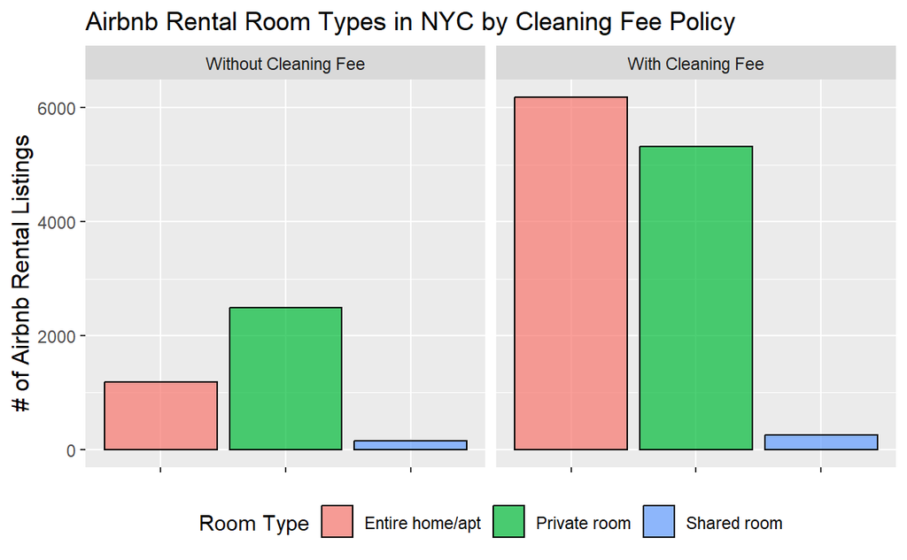

```r
ggplot(ny.df, aes(x= room_type, fill = room_type)) + geom_bar(color = "black", alpha = 0.7) + labs(title = "Airbnb Rental Room Types in NYC by Cleaning Fee Policy", x = NULL, y = "# of Airbnb Rental Listings") + theme(axis.title = element_text(size = 12), legend.position = "bottom") + scale_x_discrete(labels = NULL) + facet_wrap(~cleaning_fee, labeller = labeller(cleaning_fee = c("True" = "With Cleaning Fee", "False" = "Without Cleaning Fee"))) + scale_fill_discrete(name = "Room Type")
```

**(2) Histogram**

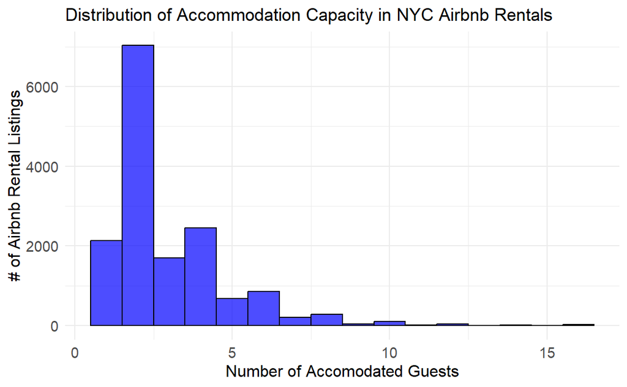

```r
ggplot(ny.df, aes(x= accommodates)) + geom_histogram(binwidth = 1, fill = "blue", color = "black", alpha = 0.7) + labs(title = "Distribution of Accommodation Capacity in NYC Airbnb Rentals", x = "Number of Accomodated Guests", y= "# of Airbnb Rental Listings") + theme_minimal() + theme(axis.text = element_text(size = 11), axis.title = element_text(size = 12))
```

**(3) Heat Map/Correlation Matrix**

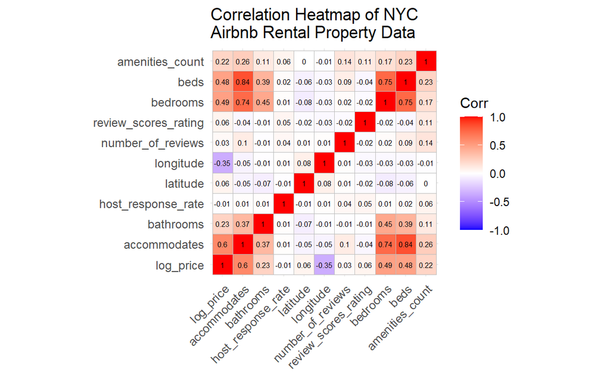

```r
library(ggcorrplot)

ggcorrplot(corr, lab = TRUE, lab_size = 2, title = "Correlation Heatmap of NYC\nAirbnb Rental Property Data") + theme(plot.title = element_text(size = 13), axis.text.x = element_text(size = 9), axis.text.y = element_text(size = 9))
```

**(4) Proportional Bar Chart**

```r
# Define new variable 'property_group' that groups property types
# (Goal = limit num. of levels)
ny.df$property_group <- ifelse(ny.df$property_type %in% c("Guesthouse", "Guest suite", "In-law"), "Guest suite/In-law",
                               ifelse(ny.df$property_type %in% c("Boutique hotel", "Dorm", "Hostel", "Serviced apartment", "Timeshare"), "Accommodation",
                                      ifelse(ny.df$property_type %in% c("Boat", "Bungalow", "Cabin", "Castle", "Chalet", "Earth House", "Tent", "Vacation home", "Villa", "Yurt"), "Specialty",
                                             as.character(ny.df$property_type))))
```

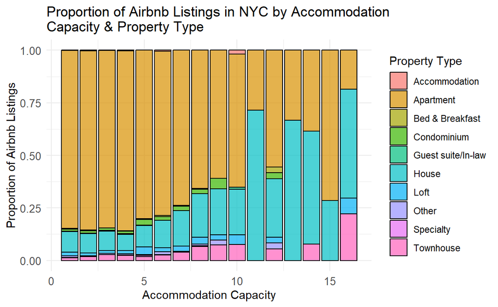

```r
# Create Stacked Bar Chart
ggplot(ny.df, aes(x= accommodates, fill = property_group)) + geom_bar(position = "fill", color = "black", alpha = 0.7) + labs(title = "Proportion of Airbnb Listings in NYC by Accommodation\nCapacity & Property Type", x = "Accommodation Capacity", y = "Proportion of Airbnb Listings") + scale_fill_discrete(name = "Property Type") + theme_minimal() +  theme(axis.text = element_text(size = 10), axis.title = element_text(size = 11))
```

**(5) Histogram #2**

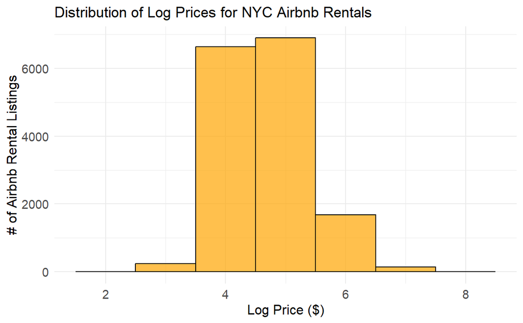

```r
ggplot(ny.df, aes(x= log_price)) + geom_histogram(binwidth = 1, fill = "orange", color = "black", alpha = 0.7) + labs(title = "Distribution of Log Prices for NYC Airbnb Rentals", x = "Log Price ($)", y= "# of Airbnb Rental Listings") + theme_minimal() + theme(axis.text = element_text(size = 11), axis.title = element_text(size = 12))
```

**(6) Scatterplot**

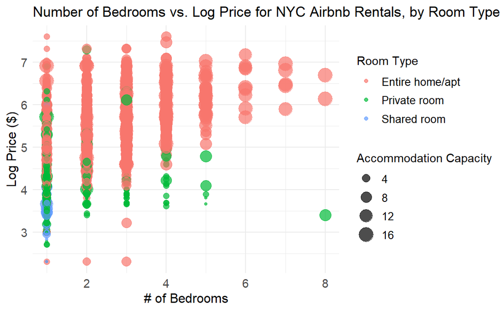

```r
ggplot(ny.df, aes(x= bedrooms, y= log_price, color = room_type, size = accommodates)) + geom_point(na.rm= TRUE, alpha = 0.7) + xlim(1, 8) + labs(title= "Number of Bedrooms vs. Log Price for NYC Airbnb Rentals, by Room Type & Accommodation Capacity", x= "# of Bedrooms", y= "Log Price ($)") + scale_color_discrete(name = "Room Type") + scale_size_continuous(name = "Accommodation Capacity") + theme_minimal() + theme(axis.text = element_text(size = 11), axis.title = element_text(size = 12), legend.text = element_text(size = 10))
```

*In this crucial phase of the data preparation and exploration process, R and the adaptable ‘ggplot2’ library within R/R Studio were employed to uncover profound insight; empowering both Airbnb users and management to make well-informed decisions and optimizing their experience in the dynamic New York City market.*

**1. Faceted Bar Chart: Understanding Cleaning Fee Policies**

Our first visualization is a faceted bar chart that meticulously dissects Airbnb rental room types in NYC based on their cleaning fee policies. By segmenting the data in this manner, we reveal valuable insights that can help both hosts and guests. For Airbnb management, this information can aid in setting competitive pricing strategies and policies for different room types. Guests can benefit from this knowledge by making more informed decisions about accommodation based on their preferences and budget. This plot uncovers that cleaning fees are prevalent, especially for ‘entire home/apartment’ listings. Such insights can guide both hosts and guests in negotiations and bookings.

**2. Histogram: Revealing Accommodation Preferences**

The second visualization, a histogram showcasing accommodation capacity distribution, lays bare the preferences of Airbnb renters in New York City. For hosts, this is a goldmine of information, allowing them to tailor their listings to the most sought-after capacities, thereby optimizing occupancy rates and revenue. For guests, this histogram is a powerful tool for finding the perfect match based on group size. It shows that most listings can comfortably host around 2 guests, but it also highlights the availability of properties for larger groups. This revelation aids in decision-making for both hosts and guests.

**4. Proportional Bar Chart: Navigating Property Types and Capacity**

The fourth visualization, a stacked bar chart, guides Airbnb management and users in understanding the distribution of property types and their capacity. This chart is an invaluable resource for hosts to fine-tune their listings based on property type and group size. Apartments emerge as the dominant choice, particularly for smaller parties. Houses, on the other hand, become more appealing for larger groups. Airbnb users can capitalize on this knowledge to make well-informed booking decisions.

**5. Histogram #2: Unearthing Pricing Patterns**

Our fifth visualization is another histogram, this time focusing on the distribution of log-transformed prices. This transformed scale can unveil hidden pricing trends or clusters that are not immediately apparent. For both hosts and guests, this histogram offers deeper insights into the nuanced price dynamics of Airbnb rentals in NYC.

**6. Scatterplot: Understanding Price Dynamics**

Lastly, our sixth plot, a scatterplot, delves into the intricate relationship between several variables: number of bedrooms, log-transformed prices, room types, and accommodation capacity. This visualization empowers both hosts and guests to decipher how these factors interact and influence rental prices. Notably, it sheds light on the price variations tied to room type and capacity, offering actionable insights for optimizing pricing strategies and booking decisions.

Together, these insightful visualizations equip Airbnb stakeholders with a wealth of information, enabling them to make data-driven decisions that enhance the Airbnb experience in New York City. Whether you’re a host seeking to maximize revenue or a guest in pursuit of the perfect stay, these visualizations are your compass in navigating the NYC Airbnb landscape.

# **2. Prediction**

## **Multiple Regression Model for Predicting Airbnb Rental Prices in NYC**

*In this portion of the project, we aim to predict Airbnb rental prices in New York City using a multiple regression model. Through data preprocessing, variable selection, and model refinement, we’ll uncover key insights that benefit both hosts and guests in this bustling metropolis.*

### **Data Pre-processing & Variable Selection**

```r
# Variable/dimension reduction
ny.df_reg <- subset(ny.df, select = -c(city, description, first_review, host_has_profile_pic, host_since, id, last_review, name, neighbourhood, property_type, thumbnail_url, beds, amenities))
```

### **Partitioning of Data - Training & Validation Sets**

```r
# Partition the data into training (60%) & validation (40%) sets
set.seed(1)

# Sample 60% of the data, which we will assign to the training data set
train.index <- sample(c(1:nrow(ny.df_reg)), nrow(ny.df_reg)*0.6)

# Assign 60% of the data that we just sampled to training set
train.df <- ny.df_reg[train.index, ]

# Assign remaining 40% of the data to validation set
valid.df <- ny.df_reg[-train.index, ]
```

### **Examine Bivariate Relationships**

Identify numeric & categorical predictor variables:

```r
# Subset numeric columns from training set while excluding 'log_price'
num_predictors <- train.df[, !(names(train.df) %in% 'log_price') & sapply(train.df, is.numeric)]

# Subset remaining (categorical) columns from training set while excluding 'log_price'
cat_predictors <- train.df[, !(names(train.df) %in% c(names(num_predictors), 'log_price'))]
```

Check for multicollinearity issues:

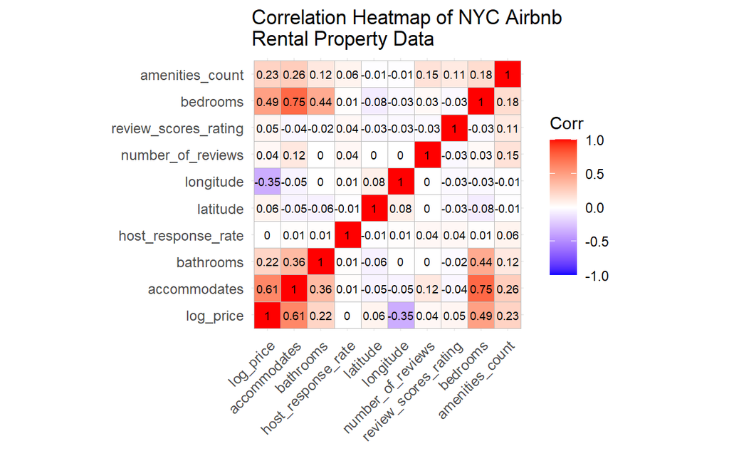

```r
# Calculate the correlation matrix with numeric variables
reg_cor_matrix <- cor(train.df[sapply(train.df, is.numeric)])

# Visualize correlation matrix
ggcorrplot(reg_cor_matrix, lab = TRUE, lab_size = 2.5, title = "Correlation Heatmap of NYC Airbnb\nRental Property Data") + theme(plot.title = element_text(size = 13), axis.text.x = element_text(size = 9), axis.text.y = element_text(size = 9))
```

Multicollinearity occurs when the input variables are highly correlated, making it challenging to distinguish the unique contribution of each variable to the model and decreasing the reliability of the model output. It should be noted that there are 2 input variables which are strongly correlated with one another - including ‘bedrooms’ and ‘accommodates’.

Nonetheless, the criterion for selecting variables to drop in the revised model was based on both their correlation with the output variable ‘log_price,’ as well as their correlation with each other. Given that ‘accommodates’ has a stronger correlation to ‘log_price’ than ‘bedrooms’, it might be wise to keep the accommodates variable and drop the ‘bedrooms’ variable in an effort to avoid multicollinearity issues. This choice ensures that we retain the most influential variables while eliminating unnecessary redundancy in the input features, ultimately improving the model’s performance and robustness.

### **Initial MLR Model**

```r
# Run MLR of 'log_price' on all the predictors in the training set

# Note: all binary nominal categorical variables will automatically be converted into dummy variables with 'm-1' dummies

mlr.model <- lm(log_price ~ ., data = train.df)
options(digits = 3, scipen = 999)
mlr_summary <- summary(mlr.model)
mlr_summary
```

```
Call:
lm(formula = log_price ~ ., data = train.df)

Residuals:
   Min     1Q Median     3Q    Max
-3.776 -0.220 -0.005  0.205  2.498

Coefficients:
                                    Estimate  Std. Error t value
(Intercept)                      -152.995926   11.985552  -12.77
room_typePrivate room              -0.555130    0.009650  -57.52
room_typeShared room               -0.857738    0.025088  -34.19
accommodates                        0.078572    0.003438   22.86
bathrooms                           0.118473    0.010769   11.00
bed_typeOther                      -0.030669    0.022912   -1.34
cancellation_policymoderate         0.009103    0.010964    0.83
cancellation_policystrict           0.028098    0.010113    2.78
cancellation_policysuper_strict     0.008489    0.363076    0.02
cleaning_feeTrue                    0.019552    0.009340    2.09
host_identity_verifiedFalse        -0.007571    0.008336   -0.91
host_response_rate                 -0.046347    0.032655   -1.42
instant_bookableFalse               0.024957    0.008644    2.89
latitude                           -1.289501    0.110798  -11.64
longitude                          -2.837563    0.133066  -21.32
number_of_reviews                  -0.000332    0.000114   -2.91
review_scores_rating                0.313404    0.046890    6.68
bedrooms                            0.103285    0.009073   11.38
boroughBrooklyn                    -0.201629    0.033654   -5.99
boroughManhattan                    0.240371    0.030751    7.82
boroughOther                        0.220213    0.076684    2.87
boroughQueens                      -0.014867    0.032333   -0.46
boroughStaten Island               -0.945791    0.061140  -15.47
amenities_count                     0.005530    0.000546   10.12
property_groupApartment            -0.266317    0.079356   -3.36
property_groupBed & Breakfast       0.043433    0.105730    0.41
property_groupCondominium          -0.029238    0.085598   -0.34
property_groupGuest suite/In-law   -0.313871    0.122832   -2.56
property_groupHouse                -0.253748    0.080279   -3.16
property_groupLoft                 -0.017377    0.084315   -0.21
property_groupOther                -0.230229    0.093309   -2.47
```

[output cut: 27 more lines]

```
property_groupApartment                       0.00079 ***
property_groupBed & Breakfast                 0.68124
property_groupCondominium                     0.73268
property_groupGuest suite/In-law              0.01063 *
property_groupHouse                           0.00158 **
property_groupLoft                            0.83672
property_groupOther                           0.01363 *
property_groupSpecialty                       0.34137
property_groupTownhouse                       0.00506 **
---
Signif. codes:  0 ‘***’ 0.001 ‘**’ 0.01 ‘*’ 0.05 ‘.’ 0.1 ‘ ’ 1

Residual standard error: 0.362 on 9320 degrees of freedom
Multiple R-squared:  0.697, Adjusted R-squared:  0.696
F-statistic:  670 on 32 and 9320 DF,  p-value: <0.0000000000000002
```

```r
# Summary of residuals for initial MLR model (training set)
summary(mlr.model$residuals)
```

```
   Min. 1st Qu.  Median    Mean 3rd Qu.    Max.
  -3.78   -0.22   -0.01    0.00    0.20    2.50
```

```r
# Assess accuracy of initial model against training set
accuracy(mlr.model$fitted.values, train.df$log_price)
```

```
                             ME  RMSE   MAE    MPE MAPE
Test set -0.0000000000000000179 0.362 0.271 -0.612 5.91
```

In an effort to improve the predictive accuracy of the model, we will further refine the model by eliminating predictor variables in which the resulting p-value is greater than 0.05 – suggesting those specific predictor variables are not linearly related to the output variable of ‘log_price’ when controlling for other variables. As such, we will drop predictor variables such as ‘bed_type’, ‘host_identity_verified’, and ‘host_response_rate’ from the model in which the p-value is greater than 0.05. We will also drop the ‘bedrooms’ variable that is strongly correlated with the ‘accommodates’ variable to evaluate the potential impact of multicollinearity on the model’s predictive accuracy. However, we will keep some of the categorical variables where many of the categories for these variables are significant (e.g., ‘borough’ & ‘cancellation_policy’).

```r
# Drop insignificant predictor variables
train.df2 <- subset(train.df, select = -c(bed_type, host_response_rate, host_identity_verified, bedrooms))
```

```r
# Refined MLR model
mlr.model.2 <- lm(log_price ~ ., data = train.df2)
summary(mlr.model.2)
```

```
Call:
lm(formula = log_price ~ ., data = train.df2)

Residuals:
   Min     1Q Median     3Q    Max
-3.770 -0.225 -0.005  0.207  2.498

Coefficients:
                                    Estimate  Std. Error t value
(Intercept)                      -153.083571   12.064594  -12.69
room_typePrivate room              -0.556466    0.009703  -57.35
room_typeShared room               -0.864763    0.024622  -35.12
accommodates                        0.102788    0.002723   37.75
bathrooms                           0.148792    0.010503   14.17
cancellation_policymoderate         0.006691    0.011009    0.61
cancellation_policystrict           0.029588    0.010156    2.91
cancellation_policysuper_strict     0.008367    0.365579    0.02
cleaning_feeTrue                    0.018147    0.009380    1.93
instant_bookableFalse               0.030247    0.008607    3.51
latitude                           -1.303542    0.111538  -11.69
longitude                          -2.845867    0.133944  -21.25
number_of_reviews                  -0.000431    0.000114   -3.79
review_scores_rating                0.315799    0.047161    6.70
boroughBrooklyn                    -0.194922    0.033863   -5.76
boroughManhattan                    0.244796    0.030945    7.91
boroughOther                        0.227573    0.077210    2.95
boroughQueens                      -0.011433    0.032533   -0.35
boroughStaten Island               -0.941649    0.061515  -15.31
amenities_count                     0.005391    0.000549    9.83
property_groupApartment            -0.248340    0.079853   -3.11
property_groupBed & Breakfast       0.080626    0.106355    0.76
property_groupCondominium          -0.021143    0.086132   -0.25
property_groupGuest suite/In-law   -0.302503    0.123567   -2.45
property_groupHouse                -0.227057    0.080748   -2.81
property_groupLoft                  0.002708    0.084837    0.03
property_groupOther                -0.211535    0.093899   -2.25
property_groupSpecialty            -0.105026    0.126079   -0.83
property_groupTownhouse            -0.209848    0.083701   -2.51
                                             Pr(>|t|)
(Intercept)                      < 0.0000000000000002 ***
```

[output cut: 19 more lines]

```
property_groupApartment                       0.00188 **
property_groupBed & Breakfast                 0.44842
property_groupCondominium                     0.80610
property_groupGuest suite/In-law              0.01438 *
property_groupHouse                           0.00493 **
property_groupLoft                            0.97454
property_groupOther                           0.02430 *
property_groupSpecialty                       0.40486
property_groupTownhouse                       0.01219 *
---
Signif. codes:  0 ‘***’ 0.001 ‘**’ 0.01 ‘*’ 0.05 ‘.’ 0.1 ‘ ’ 1

Residual standard error: 0.365 on 9324 degrees of freedom
Multiple R-squared:  0.693, Adjusted R-squared:  0.692
F-statistic:  751 on 28 and 9324 DF,  p-value: <0.0000000000000002
```

```r
# Assess accuracy of refined model against training set
accuracy(mlr.model.2$fitted.values, train.df$log_price)
```

```
                             ME  RMSE   MAE    MPE MAPE
Test set 0.00000000000000000228 0.364 0.273 -0.618 5.96
```

*Stepwise Regression*

```r
# Apply stepwise regression, which drops predictors that lack statistical significance from the intial MLR model in an effort to determine the best subset of predictor variables
mlr.model.step <- step(mlr.model, direction = "both")
```

```
Start:  AIC=-18965
log_price ~ room_type + accommodates + bathrooms + bed_type +
    cancellation_policy + cleaning_fee + host_identity_verified +
    host_response_rate + instant_bookable + latitude + longitude +
    number_of_reviews + review_scores_rating + bedrooms + borough +
    amenities_count + property_group

                         Df Sum of Sq  RSS    AIC
- host_identity_verified  1         0 1223 -18966
- bed_type                1         0 1223 -18965
<none>                                1223 -18965
- host_response_rate      1         0 1223 -18965
- cleaning_fee            1         1 1223 -18963
- cancellation_policy     3         1 1224 -18962
- instant_bookable        1         1 1224 -18959
- number_of_reviews       1         1 1224 -18959
- review_scores_rating    1         6 1228 -18922
- amenities_count         1        13 1236 -18865
- bathrooms               1        16 1238 -18846
- bedrooms                1        17 1240 -18838
- latitude                1        18 1240 -18832
- property_group          9        21 1243 -18827
- longitude               1        60 1282 -18522
- accommodates            1        69 1291 -18457
- borough                 5       200 1422 -17560
- room_type               2       481 1704 -15864

Step:  AIC=-18966
log_price ~ room_type + accommodates + bathrooms + bed_type +
    cancellation_policy + cleaning_fee + host_response_rate +
    instant_bookable + latitude + longitude + number_of_reviews +
    review_scores_rating + bedrooms + borough + amenities_count +
    property_group

                         Df Sum of Sq  RSS    AIC
- bed_type                1         0 1223 -18967
- host_response_rate      1         0 1223 -18966
<none>                                1223 -18966
+ host_identity_verified  1         0 1223 -18965
- cleaning_fee            1         1 1223 -18964
```

[output cut: 50 more lines]

```
+ host_identity_verified  1         0 1223 -18965
- cleaning_fee            1         1 1224 -18964
- cancellation_policy     3         1 1224 -18963
- number_of_reviews       1         1 1224 -18960
- instant_bookable        1         1 1224 -18959
- review_scores_rating    1         6 1229 -18924
- amenities_count         1        13 1237 -18866
- bathrooms               1        16 1239 -18848
- bedrooms                1        17 1240 -18840
- latitude                1        18 1241 -18833
- property_group          9        20 1244 -18829
- longitude               1        60 1283 -18522
- accommodates            1        69 1292 -18457
- borough                 5       200 1423 -17561
- room_type               2       490 1713 -15819
```

```r
summary(mlr.model.step)
```

```
Call:
lm(formula = log_price ~ room_type + accommodates + bathrooms +
    cancellation_policy + cleaning_fee + instant_bookable + latitude +
    longitude + number_of_reviews + review_scores_rating + bedrooms +
    borough + amenities_count + property_group, data = train.df)

Residuals:
   Min     1Q Median     3Q    Max
-3.782 -0.220 -0.005  0.205  2.494

Coefficients:
                                    Estimate  Std. Error t value
(Intercept)                      -153.171089   11.982785  -12.78
room_typePrivate room              -0.555680    0.009637  -57.66
room_typeShared room               -0.864362    0.024455  -35.34
accommodates                        0.078718    0.003437   22.90
bathrooms                           0.118450    0.010769   11.00
cancellation_policymoderate         0.009132    0.010937    0.83
cancellation_policystrict           0.028828    0.010087    2.86
cancellation_policysuper_strict     0.010756    0.363100    0.03
cleaning_feeTrue                    0.020145    0.009318    2.16
instant_bookableFalse               0.026408    0.008555    3.09
latitude                           -1.291892    0.110786  -11.66
longitude                          -2.840681    0.133036  -21.35
number_of_reviews                  -0.000332    0.000113   -2.93
review_scores_rating                0.311634    0.046842    6.65
bedrooms                            0.102938    0.009072   11.35
boroughBrooklyn                    -0.203238    0.033641   -6.04
boroughManhattan                    0.238550    0.030741    7.76
boroughOther                        0.221105    0.076689    2.88
boroughQueens                      -0.017016    0.032317   -0.53
boroughStaten Island               -0.949962    0.061103  -15.55
amenities_count                     0.005524    0.000545   10.14
property_groupApartment            -0.270229    0.079335   -3.41
property_groupBed & Breakfast       0.038132    0.105701    0.36
property_groupCondominium          -0.033596    0.085555   -0.39
property_groupGuest suite/In-law   -0.319502    0.122739   -2.60
property_groupHouse                -0.258196    0.080247   -3.22
property_groupLoft                 -0.021575    0.084289   -0.26
property_groupOther                -0.234350    0.093284   -2.51
```

[output cut: 24 more lines]

```
property_groupApartment                       0.00066 ***
property_groupBed & Breakfast                 0.71829
property_groupCondominium                     0.69456
property_groupGuest suite/In-law              0.00925 **
property_groupHouse                           0.00130 **
property_groupLoft                            0.79798
property_groupOther                           0.01201 *
property_groupSpecialty                       0.31682
property_groupTownhouse                       0.00428 **
---
Signif. codes:  0 ‘***’ 0.001 ‘**’ 0.01 ‘*’ 0.05 ‘.’ 0.1 ‘ ’ 1

Residual standard error: 0.362 on 9323 degrees of freedom
Multiple R-squared:  0.697, Adjusted R-squared:  0.696
F-statistic:  739 on 29 and 9323 DF,  p-value: <0.0000000000000002
```

```r
# Assess accuracy of initial model after applying stepwise regression
accuracy(mlr.model.step$fitted.values, train.df$log_price)
```

```
                             ME  RMSE   MAE    MPE MAPE
Test set 0.00000000000000000111 0.362 0.271 -0.613 5.92
```

- The initial model with both ‘Accommodates’ and ‘Bedrooms’ has a slightly higher adjusted R-squared value, indicating that it explains a bit more of the variance in ‘log_price’ compared to the refined model.
- The RMSE of the initial model is slightly lower, which means it has slightly better predictive accuracy in terms of the error between predicted and actual ‘log_price’ values (i.e., initial model may provide a slightly better fit to the data for prediction purposes).

### **Model Evaluation**

```r
# Fitting MLR model to validation data & measuring model accuracy
library (forecast)  # load 'forecast' package for predictions

# Initial model
mlr.pred <- predict(mlr.model, newdata= valid.df)
accuracy(mlr.pred, valid.df$log_price)
```

```
                ME  RMSE   MAE    MPE MAPE
Test set -0.000479 0.362 0.274 -0.629 5.98
```

```r
# Refined model
mlr.2.pred <- predict(mlr.model.2, newdata= valid.df)
accuracy(mlr.2.pred, valid.df$log_price)
```

```
                ME  RMSE   MAE   MPE MAPE
Test set -0.000222 0.365 0.276 -0.63 6.04
```

```r
# Intial model + Stepwise regression
mlr.step.pred <- predict(mlr.model.step, newdata= valid.df)
accuracy(mlr.step.pred, valid.df$log_price)
```

```
                ME  RMSE   MAE    MPE MAPE
Test set -0.000355 0.362 0.274 -0.627 5.99
```

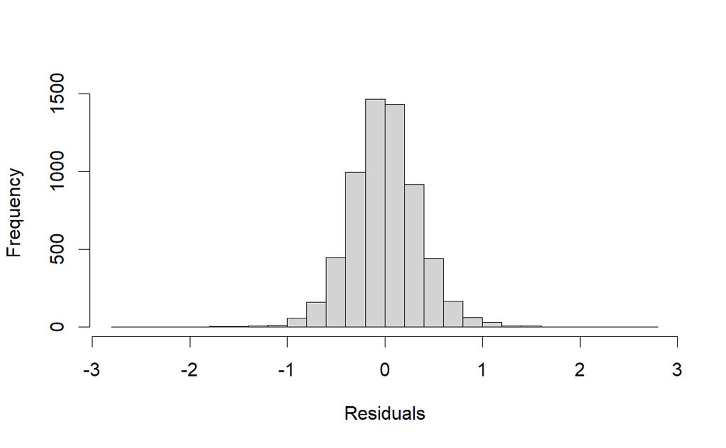

```r
all.residuals <- valid.df$log_price - mlr.step.pred
hist(all.residuals, breaks = 25, xlab = "Residuals", main = " ")
```

Based on the histogram of residual errors when the model is fit to the validation data, one can conclude that most errors are between -1 and 1 (i.e., error magnitude).

### **Summary of MLR Modeling Process:**

In this phase of the data mining project, the primary objective was to construct a robust multiple linear regression (MLR) model capable of predicting the logarithm of rental property prices (‘log_price’) on Airbnb listings in New York City. The modeling process was characterized by careful consideration of various factors to strike a balance between predictive accuracy and model interpretability, ensuring the final model’s reliability.

The process began with thorough data preprocessing, which included addressing missing values and filtering out any data points that appeared unrealistic. This rigorous data preparation was fundamental to ensuring the model’s quality.

One of the pivotal decisions in variable selection was tackling multicollinearity among predictor variables. A strong correlation was observed between ‘bedrooms’ and ‘accommodates.’ To maintain model stability and interpretability, ‘accommodates’ was retained, given its stronger correlation with ‘log_price.’ Additionally, certain categorical variables like ‘bed_type’ and ‘cancellation_policy’ were streamlined to enhance the model’s efficiency.

The stepwise regression technique was employed to further refine the model by eliminating variables with p-values exceeding 0.05, indicating a lack of a significant linear relationship with ‘log_price.’ However, certain categorical variables such as ‘borough’ and ‘cancellation_policy’ were judiciously retained due to their demonstrated statistical significance.

The overarching goal throughout this process was to create a parsimonious yet accurate MLR model. After comparing two models—one with both ‘bedrooms’ and ‘accommodates’ and another with only ‘accommodates’—it was concluded that the initial model, which included both variables, provided a slightly better fit to the data for prediction purposes. Therefore, the initial model was selected as the preferred choice, aligning with the primary aim of maximizing predictive accuracy.

In summary, the modeling process was a thoughtful and meticulous journey, guided by a commitment to optimizing the predictive performance of the MLR model while maintaining its interpretability and reliability. The selected model, with ‘bedrooms’ and ‘accommodates’ as predictors, serves as a robust tool for predicting Airbnb listing prices in the vibrant city of New York.

### **Key Findings:**

In conclusion, the multiple regression model provides valuable insights into the factors influencing Airbnb rental prices in New York City. It suggests that accommodation capacity, the number of available amenities, location, and past ratings/reviews significantly impact rental prices. The model explains a substantial portion of the price variability, but further research could explore additional factors to enhance predictive accuracy. The insights obtained from the model output highlight the importance of considering these factors when setting rental prices on the Airbnb platform, ultimately aiding both hosts and guests in making informed decisions.

# **3. Classification**

## **a. k-Nearest Neighbors**

### **Data Pre-processing & Partitioning**

```r
# Convert the predictive outcome of 'cleaning_fee' into a factor
ny_k.df <- ny.df
ny_k.df$cleaning_fee <- as.factor(ny.df$cleaning_fee)
str(ny_k.df$cleaning_fee)
```

```
 Factor w/ 2 levels "False","True": 2 2 2 2 2 2 2 1 2 2 ...
```

```r
# Remove columns not used as predictors (i.e., variables not relevant to cleaning fees)
ny_k.df <- subset(ny_k.df, select = -c(id, amenities, bed_type, city, description, first_review, host_has_profile_pic, host_identity_verified, host_response_rate, host_since, last_review, name, neighbourhood, thumbnail_url, property_group))

summary(ny_k.df)
```

```
   log_price    property_type       room_type          accommodates
 Min.   :2.30   Length:15589       Length:15589       Min.   : 1.00
 1st Qu.:4.17   Class :character   Class :character   1st Qu.: 2.00
 Median :4.61   Mode  :character   Mode  :character   Median : 2.00
 Mean   :4.68                                         Mean   : 2.96
 3rd Qu.:5.11                                         3rd Qu.: 4.00
 Max.   :7.60                                         Max.   :16.00
   bathrooms      cancellation_policy cleaning_fee  instant_bookable
 Min.   :0.50   flexible    :3735     False: 3822   True : 4237
 1st Qu.:1.00   moderate    :4050     True :11767   False:11352
 Median :1.00   strict      :7801
 Mean   :1.14   super_strict:   3
 3rd Qu.:1.00
 Max.   :5.50
    latitude      longitude     number_of_reviews review_scores_rating
 Min.   :40.5   Min.   :-74.2   Min.   :  1       Min.   :0.200
 1st Qu.:40.7   1st Qu.:-74.0   1st Qu.:  3       1st Qu.:0.910
 Median :40.7   Median :-74.0   Median :  9       Median :0.960
 Mean   :40.7   Mean   :-74.0   Mean   : 23       Mean   :0.935
 3rd Qu.:40.8   3rd Qu.:-73.9   3rd Qu.: 29       3rd Qu.:1.000
 Max.   :40.9   Max.   :-73.7   Max.   :465       Max.   :1.000
    bedrooms          beds         borough          amenities_count
 Min.   : 1.00   Min.   : 1.00   Length:15589       Min.   : 1.0
 1st Qu.: 1.00   1st Qu.: 1.00   Class :character   1st Qu.:13.0
 Median : 1.00   Median : 1.00   Mode  :character   Median :16.0
 Mean   : 1.28   Mean   : 1.64                      Mean   :17.4
 3rd Qu.: 1.00   3rd Qu.: 2.00                      3rd Qu.:21.0
 Max.   :10.00   Max.   :18.00                      Max.   :77.0
```

```r
# Set seed with value 60 & partition the dataset into training (60%) & validation (40%) sets
set.seed(60)  # Set the seed here
ny_k.df_train.index <- sample(c(1:nrow(ny_k.df)), nrow(ny_k.df) * 0.6)
ny_k_train.df <- ny_k.df[ny_k.df_train.index, ]
ny_k_valid.df <- ny_k.df[-ny_k.df_train.index, ]
```

### **Separate Rentals**

```r
# Separate the rentals with/without a cleaning fee in training set
train.df_t <- subset(ny_k_train.df, cleaning_fee == "True")
train.df_f <- subset(ny_k_train.df, cleaning_fee == "False")
```

### **Examine Differences in Mean Values**

```r
# Examine the percentage difference in the mean value among the numeric predictor variables
(mean(train.df_t$log_price) - mean(train.df_f$log_price)) * 100
```

```
[1] 28.6
```

```r
(mean(train.df_t$accommodates) - mean(train.df_f$accommodates)) * 100
```

```
[1] 83.2
```

```r
(mean(train.df_t$bathrooms) - mean(train.df_f$bathrooms)) * 100
```

```
[1] 3.08
```

```r
(mean(train.df_t$bedrooms) - mean(train.df_f$bedrooms)) * 100
```

```
[1] 16.3
```

```r
(mean(train.df_t$beds) - mean(train.df_f$beds)) * 100
```

```
[1] 37.2
```

### **Variable Selection**

```r
# If any variables are categorical or show less than 10% difference in mean value between the two groups, remove those variables entirely
ny_k_train.df <- subset(ny_k_train.df, select = -c(bathrooms, property_type, room_type, cancellation_policy, borough, instant_bookable))
ny_k_valid.df <- subset(ny_k_valid.df, select = -c(bathrooms, property_type, room_type, cancellation_policy, borough, instant_bookable))
ny_k.df <- subset(ny_k.df, select = -c(bathrooms, property_type, room_type, cancellation_policy, borough, instant_bookable))
str(ny_k_train.df)
```

```
'data.frame':   9353 obs. of  10 variables:
 $ log_price           : num  5.16 5.25 4.6 3.4 4.78 ...
 $ accommodates        : int  4 4 2 2 2 2 2 4 2 4 ...
 $ cleaning_fee        : Factor w/ 2 levels "False","True": 2 2 2 2 1 2 2 2 2 1 ...
 $ latitude            : num  40.7 40.8 40.7 40.7 40.7 ...
 $ longitude           : num  -74 -73.9 -73.9 -74 -74 ...
 $ number_of_reviews   : int  3 10 126 1 1 56 18 31 105 11 ...
 $ review_scores_rating: num  0.8 1 0.98 1 1 0.98 0.93 0.89 0.9 0.98 ...
 $ bedrooms            : num  1 1 1 1 1 1 1 1 1 1 ...
 $ beds                : num  1 2 1 1 1 1 1 2 1 1 ...
 $ amenities_count     : int  18 17 20 7 9 12 23 16 19 10 ...
```

### **Normalization**

```r
# Normalize the data using the training set & 'preProcess()' function.
library(caret)  # Load the caret library
train.norm.df <- ny_k_train.df
valid.norm.df <- ny_k_valid.df
ny_k.norm.df <- ny_k.df

# Specify the columns to normalize
columns_to_normalize <- c("log_price", "accommodates", "bedrooms", "beds")

# Create a preProcess object
norm_values <- preProcess(ny_k_train.df[, columns_to_normalize], method = c("center", "scale"))

# Apply normalization to the training and validation data
train.norm.df[, columns_to_normalize] <- predict(norm_values, ny_k_train.df[, columns_to_normalize])
valid.norm.df[, columns_to_normalize] <- predict(norm_values, ny_k_valid.df[, columns_to_normalize])
ny_k.norm.df[, columns_to_normalize] <- predict(norm_values, ny_k.df[, columns_to_normalize])
```

### **Create New Rental**

```r
# Make up a new rental to predict/classify the cleaning fee to train the model
new.df <- data.frame(log_price = 4, accommodates = 5, bedrooms = 4, beds = 5)

# Ensure that the columns in new.df match the columns used for normalization in the training data
new.df[, columns_to_normalize] <- predict(norm_values, new.df[, columns_to_normalize])
```

### **k-nn Model Evaluation**

```r
# Using the validation data and a range of k values from 1 to 14, access the accuracy level for each k value from 1 to 14

# Initialize a data frame with two columns: k, & accuracy
accuracy.df <- data.frame(k = seq(1, 14, 1), accuracy = rep(0, 14))

# Compute the accuracy level for each k value & find the optimal k-value
for (i in 1:14) {
  knn.pred <- knn(train.norm.df[, columns_to_normalize], valid.norm.df[, columns_to_normalize], cl = train.norm.df[, "cleaning_fee"], k = i)
  accuracy.df[i, 2] <- confusionMatrix(knn.pred, valid.norm.df[, "cleaning_fee"])$overall[1]
}

accuracy.df
```

| k | accuracy |
| --- | --- |
| 1 | 0.664 |
| 2 | 0.570 |
| 3 | 0.693 |
| 4 | 0.647 |
| 5 | 0.715 |
| 6 | 0.694 |
| 7 | 0.720 |
| 8 | 0.712 |
| 9 | 0.730 |
| 10 | 0.715 |

[output cut: 4 more lines]

### **k-nn Model Prediction**

```r
# Using the knn() function, the normalized training data, & the optimal k=11, generate a predicted classification of cleaning_fee for the new rental.
optimal_k <- which.max(accuracy.df$accuracy)
optimal_k_value <- accuracy.df$k[optimal_k]

nn <- knn(train = train.norm.df[, columns_to_normalize], test = new.df[, columns_to_normalize], cl = train.norm.df[, "cleaning_fee"], k = optimal_k_value)
predicted_cleaning_fee <- as.character(nn)
predicted_cleaning_fee
```

```
[1] "True"
```

The prediction is ‘True’ - the fictional NYC Airbnb rental will have a cleaning fee.

### **Explanation of k-NN Model**

In the third part of the data mining project, a k-nearest neighbors (k-NN) classification model was implemented to predict whether or not an Airbnb rental in New York City would include a cleaning fee. The construction of this predictive model involved several systematic steps to ensure its reliability and accuracy.

To begin, the dataset was preprocessed by transforming the ‘cleaning_fee’ variable into a factor, representing the presence or absence of cleaning fees. Subsequently, irrelevant columns, such as URLs and non-predictive attributes, were removed from the dataset. Missing values were also handled by eliminating rows with any NA values, as k-NN models do not accommodate missing data.

To establish a robust model, the dataset was split into training and validation sets using a 60-40 partition while maintaining reproducibility through the application of a random seed. Within the training dataset, a comparative analysis of mean differences between rentals with and without cleaning fees was conducted for various predictor variables. This allowed for the identification of attributes that significantly contributed to the classification task. Variables demonstrating minimal differences or being categorical in nature were excluded from consideration to prevent potential similarity bias.

Normalization of the data was imperative to ensure that all predictor variables contributed equally to the model. The ‘preProcess’ function from the ‘caret’ package was employed to standardize the data, rendering it suitable for k-NN classification.

Subsequently, k-NN classification was performed on the validation dataset, with k values ranging from 1 to 14. Model accuracy was evaluated for each k value, and it was determined that the optimal k-value was 11, resulting in an accuracy rate of 73.3%.

Finally, the k-NN model with the optimal k-value was applied to predict whether a fictitious rental, characterized by specific attributes (log_price = 4, accommodates = 5, bedrooms = 4, beds = 5), would include a cleaning fee. The model produced a prediction of ‘True,’ indicating that the new rental was likely to have a cleaning fee.

In this instance, it is vital to address and safeguard the model against similarity bias. Similarity bias occurs when the model assigns similar instances to the same class without adequately considering individual attribute importance. This can lead to misclassification, particularly when variables exhibit strong correlations or when categorical variables are not treated with appropriate consideration. The removal of variables with minimal class differences and categorical attributes aimed to mitigate similarity bias, ensuring the model’s accuracy and fairness in classifying cleaning fees for Airbnb rentals in New York City.

## **b. Naive Bayes Classifier**

*In this section of our project, we employ the Naive Bayes algorithm to categorize NYC rental prices into four equally-sized bins: “Pricey Digs,” “Above Average,” “Below Average,” and “Student Budget.” This technique utilizes five carefully chosen predictors to make accurate predictions about price categories. The process involves rigorous model selection, training, and validation to ensure robust results.*

### **Data Pre-processing**

*Using the log_price variable, we create 4 similarly-sized bins, or categories, for the rental prices in NYC (Pricey Digs, Above Average, Below Average, Student Budget).*

```r
# Create copy of dataset & generate summary of 'log_price'
ny_nb.df<- ny.df
summary(ny_nb.df$log_price)
```

```
   Min. 1st Qu.  Median    Mean 3rd Qu.    Max.
   2.30    4.17    4.61    4.68    5.11    7.60
```

### **Binning the ‘log_price’ Variable**

```r
# Create bins for the 'log_price' variable
ny_nb.df$log_price <- cut(ny_nb.df$log_price, breaks=c(0.000, 4.248, 4.654, 5.165, 7.600), labels=c("Pricey Digs", "Above Average", "Below Average", "Student Budget"))

str(ny_nb.df$log_price)
```

```
 Factor w/ 4 levels "Pricey Digs",..: 4 3 4 3 4 3 4 4 3 4 ...
```

### **Select Predictor Variables**

```r
# Subset necessary columns
ny_nb.df <- subset(ny_nb.df, select = c(log_price, accommodates, bedrooms, bathrooms, room_type, property_type))
```

Note: Five predictors variables were selected for model building: property_type, room_type, accommodates, bathrooms, bedrooms

### **Convert Numerical Variables to Categorical**

```r
# Convert numerical variables to categorical
ny_nb.df$accommodates <- factor(ny_nb.df$accommodates)
ny_nb.df$bathrooms <- factor(ny_nb.df$bathrooms)
ny_nb.df$bedrooms <- factor(ny_nb.df$bedrooms)
```

### **Partition Dataset**

```r
# Partition dataset into training & validation sets
set.seed(60)
train_nb.index <- sample(c(1:dim(ny_nb.df)[1]), dim(ny_nb.df)[1]*0.6)
selected.var <- c(1, 2, 3, 4, 5, 6)
train_nb.df <- ny_nb.df[train_nb.index, selected.var]
valid_nb.df <- ny_nb.df[-train_nb.index, selected.var]
```

### **Naive Bayes Model**

```r
# Generate Naive Bayes model
ny_nb <- naiveBayes(log_price ~ ., data = train_nb.df)
ny_nb
```

```
Naive Bayes Classifier for Discrete Predictors

Call:
naiveBayes.default(x = X, y = Y, laplace = laplace)

A-priori probabilities:
Y
   Pricey Digs  Above Average  Below Average Student Budget
         0.279          0.261          0.237          0.224

Conditional probabilities:
                accommodates
Y                       1        2        3        4        5        6
  Pricey Digs    0.314154 0.571538 0.071346 0.034522 0.002685 0.003836
  Above Average  0.146962 0.608374 0.100575 0.109195 0.016831 0.011494
  Below Average  0.053652 0.397656 0.166366 0.230839 0.064022 0.057710
  Student Budget 0.010526 0.183732 0.112440 0.277033 0.097608 0.154067
                accommodates
Y                       7        8        9       10       11       12
  Pricey Digs    0.000767 0.000000 0.000000 0.000384 0.000000 0.000767
  Above Average  0.002053 0.002463 0.000000 0.000821 0.000411 0.000000
  Below Average  0.011722 0.013075 0.000902 0.003156 0.000451 0.000000
  Student Budget 0.038756 0.064115 0.009091 0.028230 0.003349 0.008612
                accommodates
Y                      13       14       15       16
  Pricey Digs    0.000000 0.000000 0.000000 0.000000
  Above Average  0.000000 0.000000 0.000411 0.000411
  Below Average  0.000000 0.000000 0.000000 0.000451
  Student Budget 0.001435 0.003349 0.002392 0.005263

                bedrooms
Y                       1        2        3        4        5        6
  Pricey Digs    0.976985 0.015343 0.005754 0.001151 0.000767 0.000000
  Above Average  0.933498 0.058703 0.006979 0.000821 0.000000 0.000000
  Below Average  0.773219 0.188458 0.034265 0.003607 0.000451 0.000000
  Student Budget 0.467464 0.335885 0.142584 0.036364 0.012440 0.002392
                bedrooms
Y                       7        8        9       10
  Pricey Digs    0.000000 0.000000 0.000000 0.000000
  Above Average  0.000000 0.000000 0.000000 0.000000
```

[output cut: 32 more lines]

```
  Above Average  0.000821    0.010673 0.000000    0.002053   0.001642
  Below Average  0.000902    0.013526 0.000000    0.000902   0.000451
  Student Budget 0.000478    0.023923 0.000000    0.000957   0.000000
                property_type
Y                  Hostel    House     Loft    Other Serviced apartment
  Pricey Digs    0.000384 0.164557 0.015727 0.005370           0.000000
  Above Average  0.000000 0.093186 0.012315 0.004105           0.000411
  Below Average  0.000000 0.060415 0.016231 0.007665           0.000000
  Student Budget 0.000478 0.075120 0.029187 0.003349           0.000000
                property_type
Y                Timeshare Townhouse Vacation home    Villa
  Pricey Digs     0.000000  0.021097      0.000000 0.001534
  Above Average   0.000000  0.021757      0.000000 0.000411
  Below Average   0.000451  0.022092      0.000451 0.000000
  Student Budget  0.001435  0.026794      0.000478 0.000478
```

The ‘A-priori probabilities’ given above denote the likelihood that an Airbnb listing in NYC belongs to each of these four classes. The likelihood of each class occuring in the training data is as follows: * “Pricey Digs”: 0.279 * “Above Average”: 0.261 * “Below Average”: 0.237 * “Student Budget”: 0.224

The Naive Bayes classifier will use these probabilities to make predictions. Given a set of predictor variable values for an instance, the classifier will calculate the probability of the instance belonging to each class and assign it to the most likely class (the one with the highest probability).

To demonstrate, we will predict the price class for a fictional apartment with the following characteristics: * property_type = “Apartment”, * room_type = “Entire home/apt”, * accommodates= 4, * bathrooms = 1, * bedrooms = 3

### **Predict Price Class for a Fictional Listing**

```r
# Predict probabilities & class membership for fictional listing
pred.prob <- predict(ny_nb, newdata = valid_nb.df, type = "raw")
pred.class <- predict(ny_nb, newdata = valid_nb.df)
df <- data.frame(actual = valid_nb.df$log_price, predicted = pred.class, pred.prob)
df[valid_nb.df$property_type == "Apartment" & valid_nb.df$room_type == "Entire home/apt" & valid_nb.df$accommodates == 4 &
valid_nb.df$bathrooms == 1 & valid_nb.df$bedrooms == 3,]
```

|  | actual | predicted | Pricey.Digs | Above.Average | Below.Average | Student.Budget |
| --- | --- | --- | --- | --- | --- | --- |
| 3498 | Below Average | Student Budget | 0.000209 | 0.00667 | 0.183 | 0.81 |
| 4888 | Below Average | Student Budget | 0.000209 | 0.00667 | 0.183 | 0.81 |
| 5215 | Above Average | Student Budget | 0.000209 | 0.00667 | 0.183 | 0.81 |
| 5296 | Below Average | Student Budget | 0.000209 | 0.00667 | 0.183 | 0.81 |
| 5754 | Student Budget | Student Budget | 0.000209 | 0.00667 | 0.183 | 0.81 |

### **Confusion Matrix**

```r
# Training set
pred.class <- predict(ny_nb, newdata = train_nb.df)
confusionMatrix(pred.class, train_nb.df$log_price)
```

```
Confusion Matrix and Statistics

                Reference
Prediction       Pricey Digs Above Average Below Average Student Budget
  Pricey Digs           2328          1542           471             76
  Above Average          177           230           105             42
  Below Average           82           529          1126            805
  Student Budget          20           135           516           1167

Overall Statistics

               Accuracy : 0.519
                 95% CI : (0.509, 0.529)
    No Information Rate : 0.279
    P-Value [Acc > NIR] : <0.0000000000000002

                  Kappa : 0.354

 Mcnemar's Test P-Value : <0.0000000000000002

Statistics by Class:

                     Class: Pricey Digs Class: Above Average
Sensitivity                       0.893               0.0944
Specificity                       0.690               0.9531
Pos Pred Value                    0.527               0.4152
Neg Pred Value                    0.943               0.7492
Prevalence                        0.279               0.2605
Detection Rate                    0.249               0.0246
Detection Prevalence              0.472               0.0592
Balanced Accuracy                 0.792               0.5238
                     Class: Below Average Class: Student Budget
Sensitivity                         0.508                 0.558
Specificity                         0.801                 0.908
Pos Pred Value                      0.443                 0.635
Neg Pred Value                      0.840                 0.877
Prevalence                          0.237                 0.224
Detection Rate                      0.120                 0.125
Detection Prevalence                0.272                 0.197
Balanced Accuracy                   0.655                 0.733
```

```r
# Validation set
pred.class <- predict(ny_nb, newdata = valid_nb.df)
confusionMatrix(pred.class, valid_nb.df$log_price)
```

```
Confusion Matrix and Statistics

                Reference
Prediction       Pricey Digs Above Average Below Average Student Budget
  Pricey Digs           1473           998           311             57
  Above Average          125           133            89             24
  Below Average           67           354           768            540
  Student Budget          17           109           385            786

Overall Statistics

               Accuracy : 0.507
                 95% CI : (0.494, 0.519)
    No Information Rate : 0.27
    P-Value [Acc > NIR] : <0.0000000000000002

                  Kappa : 0.339

 Mcnemar's Test P-Value : <0.0000000000000002

Statistics by Class:

                     Class: Pricey Digs Class: Above Average
Sensitivity                       0.876               0.0834
Specificity                       0.700               0.9487
Pos Pred Value                    0.519               0.3585
Neg Pred Value                    0.938               0.7509
Prevalence                        0.270               0.2556
Detection Rate                    0.236               0.0213
Detection Prevalence              0.455               0.0595
Balanced Accuracy                 0.788               0.5161
                     Class: Below Average Class: Student Budget
Sensitivity                         0.495                 0.559
Specificity                         0.795                 0.894
Pos Pred Value                      0.444                 0.606
Neg Pred Value                      0.826                 0.874
Prevalence                          0.249                 0.226
Detection Rate                      0.123                 0.126
Detection Prevalence                0.277                 0.208
Balanced Accuracy                   0.645                 0.726
```

### **Summary of Naive Bayes Classifier:**

In this section of the project, we implemented the Naive Bayes algorithm to categorize Airbnb rental prices in New York City (NYC) into four distinct bins: “Pricey Digs,” “Above Average,” “Below Average,” and “Student Budget.” This categorization allows us to provide valuable insights for both Airbnb management and potential customers. The Naive Bayes model was developed using a subset of the original data for NYC that includes five carefully chosen predictor variables: property type, room type, accommodates (the number of guests the listing can accommodate), bathrooms, and bedrooms.

The first step was to create the price bins based on the ‘log_price’ variable. We split the prices into four categories, ensuring an approximately equal distribution of listings across these categories. The summary of the ‘log_price’ variable indicates that the rental prices in NYC range from 2.30 to 7.60, with a median of 4.61. After binning, we converted the numerical predictor variables (‘accommodates,’ ‘bathrooms,’ and ‘bedrooms’) into categorical variables to prepare them for modeling.

The Naive Bayes model was then trained on a subset of the dataset, with 60% of the data used for training and the remaining 40% for validation. The model’s results are shown in the output, where it calculates conditional probabilities for each combination of predictor values in relation to the four price categories.